# INN Hotels Project

## Context

A significant number of hotel bookings are called-off due to cancellations or no-shows. The typical reasons for cancellations include change of plans, scheduling conflicts, etc. This is often made easier by the option to do so free of charge or preferably at a low cost which is beneficial to hotel guests but it is a less desirable and possibly revenue-diminishing factor for hotels to deal with. Such losses are particularly high on last-minute cancellations.

The new technologies involving online booking channels have dramatically changed customers’ booking possibilities and behavior. This adds a further dimension to the challenge of how hotels handle cancellations, which are no longer limited to traditional booking and guest characteristics.

The cancellation of bookings impact a hotel on various fronts:

- Loss of resources (revenue) when the hotel cannot resell the room.
- Additional costs of distribution channels by increasing commissions or paying for publicity to help sell these rooms.
- Lowering prices last minute, so the hotel can resell a room, resulting in reducing the profit margin.
- Human resources to make arrangements for the guests.

## Objective

The increasing number of cancellations calls for a Machine Learning based solution that can help in predicting which booking is likely to be canceled. INN Hotels Group has a chain of hotels in Portugal, they are facing problems with the high number of booking cancellations and have reached out to your firm for data-driven solutions. You as a data scientist have to analyze the data provided to find which factors have a high influence on booking cancellations, build a predictive model that can predict which booking is going to be canceled in advance, and help in formulating profitable policies for cancellations and refunds.

## Data Description

The data contains the different attributes of customers' booking details. The detailed data dictionary is given below.

**Data Dictionary**

- Booking_ID: unique identifier of each booking
- no_of_adults: Number of adults
- no_of_children: Number of Children
- no_of_weekend_nights: Number of weekend nights (Saturday or Sunday) the guest stayed or booked to stay at the hotel
- no_of_week_nights: Number of week nights (Monday to Friday) the guest stayed or booked to stay at the hotel
- type_of_meal_plan: Type of meal plan booked by the customer:
  - Not Selected – No meal plan selected
  - Meal Plan 1 – Breakfast
  - Meal Plan 2 – Half board (breakfast and one other meal)
  - Meal Plan 3 – Full board (breakfast, lunch, and dinner)
- required_car_parking_space: Does the customer require a car parking space? (0 - No, 1- Yes)
- room_type_reserved: Type of room reserved by the customer. The values are ciphered (encoded) by INN Hotels.
- lead_time: Number of days between the date of booking and the arrival date
- arrival_year: Year of arrival date
- arrival_month: Month of arrival date
- arrival_date: Date of the month
- market_segment_type: Market segment designation.
- repeated_guest: Is the customer a repeated guest? (0 - No, 1- Yes)
- no_of_previous_cancellations: Number of previous bookings that were canceled by the customer prior to the current booking
- no_of_previous_bookings_not_canceled: Number of previous bookings not canceled by the customer prior to the current booking
- avg_price_per_room: Average price per day of the reservation; prices of the rooms are dynamic. (in euros)
- no_of_special_requests: Total number of special requests made by the customer (e.g. high floor, view from the room, etc)
- booking_status: Flag indicating if the booking was canceled or not.

## Importing necessary libraries and data

```python
## lets import all relevant libraries
import pandas as pd
import numpy as np
import matplotlib.pyplot as plt
import seaborn as sns

sns.set()
```

```python
import warnings
warnings.filterwarnings('ignore')
```

## Data Overview

- Observations
- Sanity checks

```python
## load data
df = pd.read_csv("INNHotelsGroup.csv")
```

```python
## data overview
df.head()
```

|  | Booking_ID | no_of_adults | no_of_children | no_of_weekend_nights | no_of_week_nights | type_of_meal_plan | required_car_parking_space | room_type_reserved | lead_time | arrival_year | arrival_month | arrival_date | market_segment_type | repeated_guest | no_of_previous_cancellations | no_of_previous_bookings_not_canceled | avg_price_per_room | no_of_special_requests | booking_status |
| --- | --- | --- | --- | --- | --- | --- | --- | --- | --- | --- | --- | --- | --- | --- | --- | --- | --- | --- | --- |
| 0 | INN00001 | 2 | 0 | 1 | 2 | Meal Plan 1 | 0 | Room_Type 1 | 224 | 2017 | 10 | 2 | Offline | 0 | 0 | 0 | 65.00 | 0 | Not_Canceled |
| 1 | INN00002 | 2 | 0 | 2 | 3 | Not Selected | 0 | Room_Type 1 | 5 | 2018 | 11 | 6 | Online | 0 | 0 | 0 | 106.68 | 1 | Not_Canceled |
| 2 | INN00003 | 1 | 0 | 2 | 1 | Meal Plan 1 | 0 | Room_Type 1 | 1 | 2018 | 2 | 28 | Online | 0 | 0 | 0 | 60.00 | 0 | Canceled |
| 3 | INN00004 | 2 | 0 | 0 | 2 | Meal Plan 1 | 0 | Room_Type 1 | 211 | 2018 | 5 | 20 | Online | 0 | 0 | 0 | 100.00 | 0 | Canceled |
| 4 | INN00005 | 2 | 0 | 1 | 1 | Not Selected | 0 | Room_Type 1 | 48 | 2018 | 4 | 11 | Online | 0 | 0 | 0 | 94.50 | 0 | Canceled |

```python
## length of data
len(df)
```

```
36275
```

```python
## description of data
df.info()
```

```
<class 'pandas.core.frame.DataFrame'>
RangeIndex: 36275 entries, 0 to 36274
Data columns (total 19 columns):
 #   Column                                Non-Null Count  Dtype
---  ------                                --------------  -----
 0   Booking_ID                            36275 non-null  object
 1   no_of_adults                          36275 non-null  int64
 2   no_of_children                        36275 non-null  int64
 3   no_of_weekend_nights                  36275 non-null  int64
 4   no_of_week_nights                     36275 non-null  int64
 5   type_of_meal_plan                     36275 non-null  object
 6   required_car_parking_space            36275 non-null  int64
 7   room_type_reserved                    36275 non-null  object
 8   lead_time                             36275 non-null  int64
 9   arrival_year                          36275 non-null  int64
 10  arrival_month                         36275 non-null  int64
 11  arrival_date                          36275 non-null  int64
 12  market_segment_type                   36275 non-null  object
 13  repeated_guest                        36275 non-null  int64
 14  no_of_previous_cancellations          36275 non-null  int64
 15  no_of_previous_bookings_not_canceled  36275 non-null  int64
 16  avg_price_per_room                    36275 non-null  float64
 17  no_of_special_requests                36275 non-null  int64
 18  booking_status                        36275 non-null  object
dtypes: float64(1), int64(13), object(5)
memory usage: 5.3+ MB
```

```python
## let's check the summary statistics for each column
df.describe().round()
```

|  | no_of_adults | no_of_children | no_of_weekend_nights | no_of_week_nights | required_car_parking_space | lead_time | arrival_year | arrival_month | arrival_date | repeated_guest | no_of_previous_cancellations | no_of_previous_bookings_not_canceled | avg_price_per_room | no_of_special_requests |
| --- | --- | --- | --- | --- | --- | --- | --- | --- | --- | --- | --- | --- | --- | --- |
| count | 36275.0 | 36275.0 | 36275.0 | 36275.0 | 36275.0 | 36275.0 | 36275.0 | 36275.0 | 36275.0 | 36275.0 | 36275.0 | 36275.0 | 36275.0 | 36275.0 |
| mean | 2.0 | 0.0 | 1.0 | 2.0 | 0.0 | 85.0 | 2018.0 | 7.0 | 16.0 | 0.0 | 0.0 | 0.0 | 103.0 | 1.0 |
| std | 1.0 | 0.0 | 1.0 | 1.0 | 0.0 | 86.0 | 0.0 | 3.0 | 9.0 | 0.0 | 0.0 | 2.0 | 35.0 | 1.0 |
| min | 0.0 | 0.0 | 0.0 | 0.0 | 0.0 | 0.0 | 2017.0 | 1.0 | 1.0 | 0.0 | 0.0 | 0.0 | 0.0 | 0.0 |
| 25% | 2.0 | 0.0 | 0.0 | 1.0 | 0.0 | 17.0 | 2018.0 | 5.0 | 8.0 | 0.0 | 0.0 | 0.0 | 80.0 | 0.0 |
| 50% | 2.0 | 0.0 | 1.0 | 2.0 | 0.0 | 57.0 | 2018.0 | 8.0 | 16.0 | 0.0 | 0.0 | 0.0 | 99.0 | 0.0 |
| 75% | 2.0 | 0.0 | 2.0 | 3.0 | 0.0 | 126.0 | 2018.0 | 10.0 | 23.0 | 0.0 | 0.0 | 0.0 | 120.0 | 1.0 |
| max | 4.0 | 10.0 | 7.0 | 17.0 | 1.0 | 443.0 | 2018.0 | 12.0 | 31.0 | 1.0 | 13.0 | 58.0 | 540.0 | 5.0 |

```python
## let's check the data type
df.dtypes
```

```
Booking_ID                               object
no_of_adults                              int64
no_of_children                            int64
no_of_weekend_nights                      int64
no_of_week_nights                         int64
type_of_meal_plan                        object
required_car_parking_space                int64
room_type_reserved                       object
lead_time                                 int64
arrival_year                              int64
arrival_month                             int64
arrival_date                              int64
market_segment_type                      object
repeated_guest                            int64
no_of_previous_cancellations              int64
no_of_previous_bookings_not_canceled      int64
avg_price_per_room                      float64
no_of_special_requests                    int64
booking_status                           object
dtype: object
```

```python
## lets drop the id_column of the dataset
del df['Booking_ID']
```

```python
## overview of the data
df.head()
```

|  | no_of_adults | no_of_children | no_of_weekend_nights | no_of_week_nights | type_of_meal_plan | required_car_parking_space | room_type_reserved | lead_time | arrival_year | arrival_month | arrival_date | market_segment_type | repeated_guest | no_of_previous_cancellations | no_of_previous_bookings_not_canceled | avg_price_per_room | no_of_special_requests | booking_status |
| --- | --- | --- | --- | --- | --- | --- | --- | --- | --- | --- | --- | --- | --- | --- | --- | --- | --- | --- |
| 0 | 2 | 0 | 1 | 2 | Meal Plan 1 | 0 | Room_Type 1 | 224 | 2017 | 10 | 2 | Offline | 0 | 0 | 0 | 65.00 | 0 | Not_Canceled |
| 1 | 2 | 0 | 2 | 3 | Not Selected | 0 | Room_Type 1 | 5 | 2018 | 11 | 6 | Online | 0 | 0 | 0 | 106.68 | 1 | Not_Canceled |
| 2 | 1 | 0 | 2 | 1 | Meal Plan 1 | 0 | Room_Type 1 | 1 | 2018 | 2 | 28 | Online | 0 | 0 | 0 | 60.00 | 0 | Canceled |
| 3 | 2 | 0 | 0 | 2 | Meal Plan 1 | 0 | Room_Type 1 | 211 | 2018 | 5 | 20 | Online | 0 | 0 | 0 | 100.00 | 0 | Canceled |
| 4 | 2 | 0 | 1 | 1 | Not Selected | 0 | Room_Type 1 | 48 | 2018 | 4 | 11 | Online | 0 | 0 | 0 | 94.50 | 0 | Canceled |

```python
## lets check the distribution of values in the target variable.
df.booking_status.value_counts()
```

```
Not_Canceled    24390
Canceled        11885
Name: booking_status, dtype: int64
```

## Exploratory Data Analysis (EDA)

- EDA is an important part of any project involving data.
- It is important to investigate and understand the data better before building a model with it.
- A few questions have been mentioned below which will help you approach the analysis in the right manner and generate insights from the data.
- A thorough analysis of the data, in addition to the questions mentioned below, should be done.

**Leading Questions**:

1. What are the busiest months in the hotel?
2. Which market segment do most of the guests come from?
3. Hotel rates are dynamic and change according to demand and customer demographics. What are the differences in room prices in different market segments?
4. What percentage of bookings are canceled?
5. Repeating guests are the guests who stay in the hotel often and are important to brand equity. What percentage of repeating guests cancel?
6. Many guests have special requirements when booking a hotel room. Do these requirements affect booking cancellation?

```python
# function to create labeled barplots

def labeled_barplot(data, feature, perc=False, n=None):
    """
    Barplot with percentage at the top

    data: dataframe
    feature: dataframe column
    perc: whether to display percentages instead of count (default is False)
    n: displays the top n category levels (default is None, i.e., display all levels)
    """

    total = len(data[feature])  # length of the column
    count = data[feature].nunique()
    if n is None:
        plt.figure(figsize=(count + 1, 5))
    else:
        plt.figure(figsize=(n + 1, 5))

    plt.xticks(rotation=90, fontsize=15)
    ax = sns.countplot(
        data=data,
        x=feature,
        palette="Paired",
        order=data[feature].value_counts().index[:n].sort_values(),
    )

    for p in ax.patches:
        if perc == True:
            label = "{:.1f}%".format(
                100 * p.get_height() / total
            )  # percentage of each class of the category
        else:
            label = p.get_height()  # count of each level of the category

        x = p.get_x() + p.get_width() / 2  # width of the plot
        y = p.get_height()  # height of the plot

        ax.annotate(
            label,
            (x, y),
            ha="center",
            va="center",
            size=12,
            xytext=(0, 5),
            textcoords="offset points",
        )  # annotate the percentage

    plt.show()  # show the plot
```

### Plotting the busiest months in the hotel

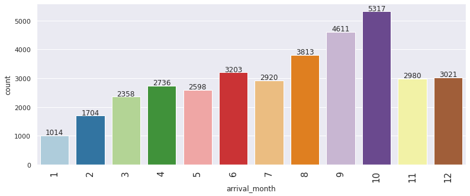

```python
labeled_barplot(df, "arrival_month")
```

### Plotting marget segment which most of the guest come from

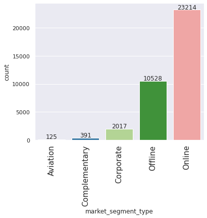

```python
labeled_barplot(df, "market_segment_type")
```

### Differences in room prices in different market segments

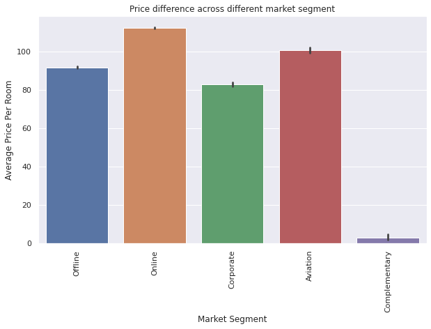

```python
plt.figure(figsize=(10, 6))
sns.barplot(data=df, x="market_segment_type", y="avg_price_per_room")

plt.title('Price difference across different market segment')
plt.xlabel('Market Segment')
plt.ylabel('Average Price Per Room')
plt.xticks(rotation=90)

plt.show()
```

### Percentage of bookings that are canceled

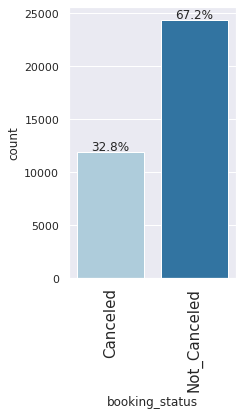

```python
labeled_barplot(df, "booking_status", perc=True,n=2)
```

### Repeating guests that cancel

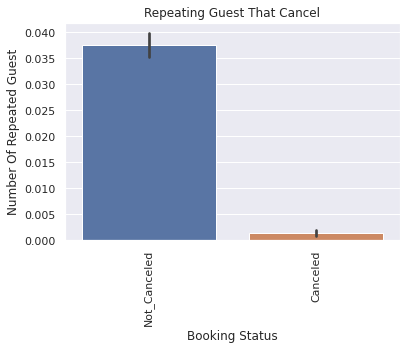

```python
plt.figure(figsize=(6, 4))
sns.barplot(data=df, x="booking_status", y="repeated_guest")

plt.title('Repeating Guest That Cancel')
plt.xlabel('Booking Status')
plt.ylabel('Number Of Repeated Guest')
plt.xticks(rotation=90)

plt.show()
```

### Special requirements that affect booking cancelation

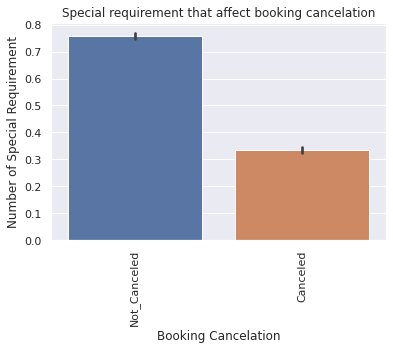

```python
plt.figure(figsize=(6, 4))
sns.barplot(data=df, x="booking_status", y="no_of_special_requests")

plt.title('Special requirement that affect booking cancelation')
plt.ylabel('Number of Special Requirement')
plt.xlabel('Booking Cancelation')
plt.xticks(rotation=90)

plt.show()
```

## EDA

- It is a good idea to explore the data once again after manipulating it.

## Data Preprocessing

- Missing value treatment (if needed)
- Feature engineering (if needed)
- Outlier detection and treatment (if needed)
- Preparing data for modeling
- Any other preprocessing steps (if needed)

```python
## lets make a copy of the dataframe
data = df.copy()
```

### Missing Value Check

```python
## lets check for missing values
data.isnull().sum()
```

```
no_of_adults                            0
no_of_children                          0
no_of_weekend_nights                    0
no_of_week_nights                       0
type_of_meal_plan                       0
required_car_parking_space              0
room_type_reserved                      0
lead_time                               0
arrival_year                            0
arrival_month                           0
arrival_date                            0
market_segment_type                     0
repeated_guest                          0
no_of_previous_cancellations            0
no_of_previous_bookings_not_canceled    0
avg_price_per_room                      0
no_of_special_requests                  0
booking_status                          0
dtype: int64
```

### Outlier Check

- Let's check for outliers in the data.

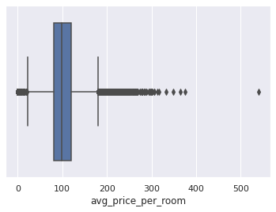

```python
## lets check the outlier distribution on the average price per room
sns.boxplot(x=data['avg_price_per_room'])

plt.show()
```

```python
print(np.where(data['avg_price_per_room'] > 300))
```

```
(array([ 4150,  9461, 13944, 14773, 20900, 25670, 33114, 33955, 34306]),)
```

```python
## all datapoint above 300 for average room price
df[np.abs(data['avg_price_per_room']) > 300]
```

|  | no_of_adults | no_of_children | no_of_weekend_nights | no_of_week_nights | type_of_meal_plan | required_car_parking_space | room_type_reserved | lead_time | arrival_year | arrival_month | arrival_date | market_segment_type | repeated_guest | no_of_previous_cancellations | no_of_previous_bookings_not_canceled | avg_price_per_room | no_of_special_requests | booking_status |
| --- | --- | --- | --- | --- | --- | --- | --- | --- | --- | --- | --- | --- | --- | --- | --- | --- | --- | --- |
| 4150 | 2 | 2 | 1 | 2 | Meal Plan 1 | 0 | Room_Type 7 | 4 | 2018 | 7 | 8 | Online | 0 | 0 | 0 | 306.00 | 3 | Not_Canceled |
| 9461 | 3 | 0 | 0 | 2 | Meal Plan 1 | 0 | Room_Type 4 | 21 | 2018 | 12 | 30 | Online | 0 | 0 | 0 | 375.50 | 0 | Not_Canceled |
| 13944 | 2 | 2 | 0 | 1 | Meal Plan 2 | 1 | Room_Type 6 | 6 | 2018 | 8 | 13 | Online | 0 | 0 | 0 | 316.00 | 0 | Canceled |
| 14773 | 2 | 2 | 0 | 3 | Meal Plan 1 | 0 | Room_Type 6 | 28 | 2018 | 6 | 2 | Online | 0 | 0 | 0 | 332.57 | 1 | Not_Canceled |
| 20900 | 2 | 1 | 1 | 2 | Meal Plan 2 | 0 | Room_Type 1 | 173 | 2018 | 7 | 25 | Offline | 0 | 0 | 0 | 365.00 | 1 | Canceled |
| 25670 | 2 | 2 | 1 | 2 | Meal Plan 2 | 0 | Room_Type 6 | 11 | 2018 | 9 | 16 | Online | 0 | 0 | 0 | 306.00 | 0 | Canceled |
| 33114 | 2 | 0 | 0 | 1 | Meal Plan 1 | 0 | Room_Type 1 | 35 | 2018 | 3 | 25 | Offline | 0 | 0 | 0 | 540.00 | 0 | Canceled |
| 33955 | 2 | 0 | 1 | 2 | Meal Plan 2 | 0 | Room_Type 4 | 57 | 2018 | 12 | 30 | Online | 0 | 0 | 0 | 314.10 | 0 | Not_Canceled |
| 34306 | 2 | 2 | 0 | 3 | Meal Plan 2 | 0 | Room_Type 6 | 43 | 2018 | 12 | 29 | Online | 0 | 0 | 0 | 349.63 | 1 | Not_Canceled |

### Outlier treatment

```python
## lets remove all data point above 300 for average room price
''' Detection '''
# IQR
Q1 = np.percentile(data['avg_price_per_room'], 25,
                   method = 'midpoint')

Q3 = np.percentile(data['avg_price_per_room'], 75,
                   method = 'midpoint')
IQR = Q3 - Q1

print("Old Shape: ", data.shape)

# Upper bound
upper = np.where(data['avg_price_per_room'] >= (Q3+1.5*IQR))
# Lower bound
lower = np.where(data['avg_price_per_room'] <= (Q1-1.5*IQR))

''' Removing the Outliers '''
data.drop(upper[0], inplace = True)
data.drop(lower[0], inplace = True)

print("New Shape: ", data.shape)
```

```
Old Shape:  (36275, 18)
New Shape:  (34579, 18)
```

```python
len(data)
```

```
34579
```

### Target Variable Conversion

```python
## let's convert our variable to numeric
data.booking_status = (data.booking_status == "Canceled").astype(int)
data.booking_status.head()
```

```
0    0
1    0
2    1
3    1
4    1
Name: booking_status, dtype: int64
```

```python
data.head().T
```

|  | 0 | 1 | 2 | 3 | 4 |
| --- | --- | --- | --- | --- | --- |
| no_of_adults | 2 | 2 | 1 | 2 | 2 |
| no_of_children | 0 | 0 | 0 | 0 | 0 |
| no_of_weekend_nights | 1 | 2 | 2 | 0 | 1 |
| no_of_week_nights | 2 | 3 | 1 | 2 | 1 |
| type_of_meal_plan | Meal Plan 1 | Not Selected | Meal Plan 1 | Meal Plan 1 | Not Selected |
| required_car_parking_space | 0 | 0 | 0 | 0 | 0 |
| room_type_reserved | Room_Type 1 | Room_Type 1 | Room_Type 1 | Room_Type 1 | Room_Type 1 |
| lead_time | 224 | 5 | 1 | 211 | 48 |
| arrival_year | 2017 | 2018 | 2018 | 2018 | 2018 |
| arrival_month | 10 | 11 | 2 | 5 | 4 |
| arrival_date | 2 | 6 | 28 | 20 | 11 |
| market_segment_type | Offline | Online | Online | Online | Online |
| repeated_guest | 0 | 0 | 0 | 0 | 0 |
| no_of_previous_cancellations | 0 | 0 | 0 | 0 | 0 |
| no_of_previous_bookings_not_canceled | 0 | 0 | 0 | 0 | 0 |
| avg_price_per_room | 65.0 | 106.68 | 60.0 | 100.0 | 94.5 |
| no_of_special_requests | 0 | 1 | 0 | 0 | 0 |
| booking_status | 0 | 0 | 1 | 1 | 1 |

### Preparing data for modeling

- Lets split the data into the following proportion
  - training set 60%
  - validation dataset 20%
  - test data 20%

```python
from sklearn.model_selection import train_test_split

df_train_full, df_test = train_test_split(data, test_size=0.2, random_state=11)

df_train, df_valid = train_test_split(df_train_full, test_size=0.25, random_state=11)
```

```python
print(f'Train set {len(df_train)}')
print(f'Valid set {len(df_valid)}')
print(f'Test set {len(df_test)}')
```

```
Train set 20747
Valid set 6916
Test set 6916
```

### Lets Select all the target

```python
## lets select the target column from the dataset
y_train = df_train.booking_status.values
y_valid = df_valid.booking_status.values
```

```python
## lets delete all the target column from the training data
del df_train['booking_status']
del df_valid['booking_status']
```

## EDA

### Target Variable Analysis

```python
## lets check for missing values in our training data
df_train_full.isnull().sum()
```

```
no_of_adults                            0
no_of_children                          0
no_of_weekend_nights                    0
no_of_week_nights                       0
type_of_meal_plan                       0
required_car_parking_space              0
room_type_reserved                      0
lead_time                               0
arrival_year                            0
arrival_month                           0
arrival_date                            0
market_segment_type                     0
repeated_guest                          0
no_of_previous_cancellations            0
no_of_previous_bookings_not_canceled    0
avg_price_per_room                      0
no_of_special_requests                  0
booking_status                          0
dtype: int64
```

```python
## letls check the distribution of the values in the target variables
df_train_full.booking_status.value_counts()
```

```
0    18475
1     9188
Name: booking_status, dtype: int64
```

```python
## lets use the mean method to calculate the cancelation rate
global_cancelation_rate = df_train_full.booking_status.mean()
round(global_cancelation_rate, 2)
```

```
0.33
```

```python
## lets create a list of categorical and numerical variables from our dataset

categorical_var = ["type_of_meal_plan", "room_type_reserved", "market_segment_type"]

numerical_var = ["no_of_adults", "no_of_children", "no_of_weekend_nights", "no_of_week_nights",
                 "required_car_parking_space", "lead_time", "arrival_year", "arrival_month",
                 "arrival_date", "repeated_guest", "no_of_previous_cancellations",
                  "no_of_previous_bookings_not_canceled", "avg_price_per_room", "no_of_special_requests"]
```

```python
## check for unique values in each categorical variables
df_train_full[categorical_var].nunique()
```

```
type_of_meal_plan      3
room_type_reserved     7
market_segment_type    5
dtype: int64
```

### Feature Importance

We are going to understand how other variable in our dataset affects the target variable book_status.

- We start by looking at categorical variables by looking at the cancel rate for each variable

```python
df_train_full['type_of_meal_plan'].unique()
```

```
array(['Meal Plan 1', 'Not Selected', 'Meal Plan 2'], dtype=object)
```

```python
## type_of_meal_plan
meal_plan_1_mean = df_train_full[df_train_full.type_of_meal_plan == 'Meal Plan 1'].booking_status.mean()
print('type_of_meal_plan == Meal Plan 1:', round(meal_plan_1_mean, 3))

meal_plan_2_mean = df_train_full[df_train_full.type_of_meal_plan == 'Meal Plan 2'].booking_status.mean()
print('type_of_meal_plan == Meal Plan 2:', round(meal_plan_2_mean, 3))

not_selected_mean = df_train_full[df_train_full.type_of_meal_plan == 'Not Selected'].booking_status.mean()
print('type_of_meal_plan == Not Selected:', round(not_selected_mean, 3))
```

```
type_of_meal_plan == Meal Plan 1: 0.317
type_of_meal_plan == Meal Plan 2: 0.462
type_of_meal_plan == Not Selected: 0.333
```

#### Observation

Customers who selected 'Meal Plan 2' are more likely to cancel their bookings than for customers who selected Meal Plan 1 and those who didn't Select any.

```python
df_train_full['room_type_reserved'].unique()
```

```
array(['Room_Type 1', 'Room_Type 4', 'Room_Type 5', 'Room_Type 2',
       'Room_Type 6', 'Room_Type 7', 'Room_Type 3'], dtype=object)
```

```python
##room_type_reserved
room_type_1 = df_train_full[df_train_full.room_type_reserved == 'Room_Type 1'].booking_status.mean()
print(f'room_type_reserved == Room_Type 1:', round(room_type_1, 3))

room_type_2 = df_train_full[df_train_full.room_type_reserved == 'Room_Type 2'].booking_status.mean()
print(f'room_type_reserved == Room_Type 2:', round(room_type_2, 3))

room_type_3 = df_train_full[df_train_full.room_type_reserved == 'Room_Type 3'].booking_status.mean()
print(f'room_type_reserved == Room_Type 3:', round(room_type_3, 3))

room_type_4 = df_train_full[df_train_full.room_type_reserved == 'Room_Type 4'].booking_status.mean()
print(f'room_type_reserved == Room_Type 4:', round(room_type_4, 3))

room_type_5 = df_train_full[df_train_full.room_type_reserved == 'Room_Type 5'].booking_status.mean()
print(f'room_type_reserved == Room_Type 5:', round(room_type_5, 3))

room_type_6 = df_train_full[df_train_full.room_type_reserved == 'Room_Type 6'].booking_status.mean()
print(f'room_type_reserved == Room_Type 6:', round(room_type_6, 3))

room_type_7 = df_train_full[df_train_full.room_type_reserved == 'Room_Type 7'].booking_status.mean()
print(f'room_type_reserved == Room_Type 7:', round(room_type_7, 3))
```

```
room_type_reserved == Room_Type 1: 0.328
room_type_reserved == Room_Type 2: 0.34
room_type_reserved == Room_Type 3: 0.4
room_type_reserved == Room_Type 4: 0.346
room_type_reserved == Room_Type 5: 0.274
room_type_reserved == Room_Type 6: 0.418
room_type_reserved == Room_Type 7: 0.2
```

From the Above result we also realised customer who selected Room_Type 6 are morely likely to cancel their reservation.

```python
df_train_full['market_segment_type'].unique()
```

```
array(['Offline', 'Online', 'Corporate', 'Aviation', 'Complementary'],
      dtype=object)
```

```python
offline = df_train_full[df_train_full.market_segment_type == 'Offline'].booking_status.mean()
print(f'market_segment_type == Offline: {round(offline, 3)}')

online = df_train_full[df_train_full.market_segment_type == 'Online'].booking_status.mean()
print(f'market_segment_type == Online: {round(online, 3)}')

corporate = df_train_full[df_train_full.market_segment_type == 'Corporate'].booking_status.mean()
print(f'market_segment_type == Corporate: {round(corporate, 3)}')

aviation = df_train_full[df_train_full.market_segment_type == 'Aviation'].booking_status.mean()
print(f'market_segment_type == Aviation: {round(aviation, 3)}')

complementary = df_train_full[df_train_full.market_segment_type == 'Complementary'].booking_status.mean()
print(f'market_segment_type == Complementary: {round(complementary, 3)}')
```

```
market_segment_type == Offline: 0.299
market_segment_type == Online: 0.369
market_segment_type == Corporate: 0.108
market_segment_type == Aviation: 0.272
market_segment_type == Complementary: 0.0
```

### Mutual Information

- Lets quantify the degree of dependency between two categorical variables

```python
from sklearn.metrics import mutual_info_score
from IPython.display import display

def calculate_mi(series):
    return mutual_info_score(series, df_train_full.booking_status)

df_mi = df_train_full[categorical_var].apply(calculate_mi)
df_mi = df_mi.sort_values(ascending=False).to_frame(name='MI')

display(df_mi.head())
```

|  | MI |
| --- | --- |
| market_segment_type | 0.010764 |
| type_of_meal_plan | 0.003575 |
| room_type_reserved | 0.000388 |

### Correlation Coefficient

We use correlation coefficient to measure the binary target variable and a numerical variable.

- A positive correlation means that when one variable goes up, the other variable tends to go up as well
- Negative correlation occurs when one variable goes up and the other goes down.
- Zero correlatin means no relationship b/n two variables

```python
df_train_full[numerical_var].corrwith(df_train_full.booking_status).to_frame('correlation')
```

|  | correlation |
| --- | --- |
| no_of_adults | 0.081386 |
| no_of_children | 0.020881 |
| no_of_weekend_nights | 0.053985 |
| no_of_week_nights | 0.080151 |
| required_car_parking_space | -0.085203 |
| lead_time | 0.439571 |
| arrival_year | 0.176516 |
| arrival_month | -0.010495 |
| arrival_date | 0.006230 |
| repeated_guest | -0.101055 |
| no_of_previous_cancellations | -0.030056 |
| no_of_previous_bookings_not_canceled | -0.055324 |
| avg_price_per_room | 0.131035 |
| no_of_special_requests | -0.247688 |

### Feature Engineering

We are going to use one-hot encoding to convert all categorical variables to numerical variable for training.

- lets encode our categorical variables in the our dataframe
- Implement our DictVectorizer

```python
df_train = df_train[categorical_var + numerical_var]
```

```python
## lets convert our train_data into a dictionary format
train_dict = df_train.to_dict(orient="records")
valid_dict = df_valid.to_dict(orient="records")
```

```python
## implementing one-hot encoding on the dataset for training
from sklearn.feature_extraction import DictVectorizer

dict_vec = DictVectorizer(sparse=False)
#dict_vec.fit(train_dict)

X_train = dict_vec.fit_transform(train_dict)
X_valid = dict_vec.transform(valid_dict)
```

```python
X_train.shape
```

```
(20747, 29)
```

```python
X_valid.shape
```

```
(6916, 29)
```

## Building a Logistic Regression model

```python
from sklearn.linear_model import LogisticRegression

log_reg_model = LogisticRegression(solver='liblinear', random_state=11)
log_reg_model.fit(X_train, y_train)
```

```
LogisticRegression(random_state=11, solver='liblinear')
```

## Model performance evaluation

- We would be implementing the Area under the ROC to evaluate our models performs

### Area under the ROC curve (AUC)

AUC is also a metric for evaluating the performance of a binary classification model.

- An AUC of 0.9 is indicative of a reasonably good model; 0.8 is okay, 0.7 is not very performant, and 0.6 indicates quite poor performance.

```python
## lets generate our model predictions using the validation dataset
y_pred = log_reg_model.predict_proba(X_valid)[:,1]
```

```python
from sklearn.metrics import roc_auc_score

acc = roc_auc_score(y_valid, y_pred)
print(f"Validation Accuracy Of AUC: {acc}")
```

```
Validation Accuracy Of AUC: 0.8543336503256205
```

## Checking Multicollinearity

- In order to make statistical inferences from a logistic regression model, it is important to ensure that there is no multicollinearity present in the data.

```python
def multicollinearity_assumption(model, features, label, feature_names=None):
    """
    Multicollinearity: Assumes that predictors are not correlated with each other. If there is
                       correlation among the predictors, then either remove prepdictors with high
                       Variance Inflation Factor (VIF) values or perform dimensionality reduction

                       This assumption being violated causes issues with interpretability of the
                       coefficients and the standard errors of the coefficients.
    """
    from statsmodels.stats.outliers_influence import variance_inflation_factor
    print('Assumption 3: Little to no multicollinearity among predictors')

    # Plotting the heatmap
    plt.figure(figsize = (10,8))
    sns.heatmap(pd.DataFrame(features, columns=feature_names).corr(), annot=True)
    plt.title('Correlation of Variables')
    plt.show()

    print('Variance Inflation Factors (VIF)')
    print('> 10: An indication that multicollinearity may be present')
    print('> 100: Certain multicollinearity among the variables')
    print('-------------------------------------')

    # Gathering the VIF for each variable
    VIF = [variance_inflation_factor(features, i) for i in range(features.shape[1])]
    for idx, vif in enumerate(VIF):
        print('{0}: {1}'.format(feature_names[idx], vif))

    # Gathering and printing total cases of possible or definite multicollinearity
    possible_multicollinearity = sum([1 for vif in VIF if vif > 10])
    definite_multicollinearity = sum([1 for vif in VIF if vif > 100])
    print()
    print('{0} cases of possible multicollinearity'.format(possible_multicollinearity))
    print('{0} cases of definite multicollinearity'.format(definite_multicollinearity))
    print()

    if definite_multicollinearity == 0:
        if possible_multicollinearity == 0:
            print('Assumption satisfied')
        else:
            print('Assumption possibly satisfied')
            print()
            print('Coefficient interpretability may be problematic')
            print('Consider removing variables with a high Variance Inflation Factor (VIF)')

    else:
        print('Assumption not satisfied')
        print()
        print('Coefficient interpretability will be problematic')
        print('Consider removing variables with a high Variance Inflation Factor (VIF)')
```

```
Assumption 3: Little to no multicollinearity among predictors
```

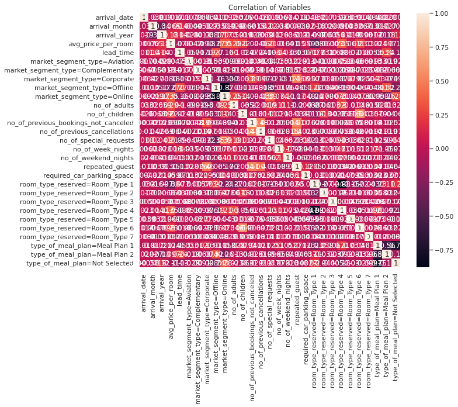

```
Variance Inflation Factors (VIF)
> 10: An indication that multicollinearity may be present
> 100: Certain multicollinearity among the variables
-------------------------------------
arrival_date: 1.0073027249080904
arrival_month: 1.28445275779354
arrival_year: 1.440944901198689
avg_price_per_room: 1.7248355314112842
lead_time: 1.394873016429016
market_segment_type=Aviation: inf
market_segment_type=Complementary: inf
market_segment_type=Corporate: inf
market_segment_type=Offline: inf
market_segment_type=Online: inf
no_of_adults: 1.32964583903019
no_of_children: 1.5734552231466772
no_of_previous_bookings_not_canceled: 1.5778123399630524
no_of_previous_cancellations: 1.3912276748489194
no_of_special_requests: 1.2553698815253138
no_of_week_nights: 1.0963250647278042
no_of_weekend_nights: 1.0741583096214982
repeated_guest: 1.7325594552088182
required_car_parking_space: 1.0400476835457437
room_type_reserved=Room_Type 1: inf
room_type_reserved=Room_Type 2: inf
room_type_reserved=Room_Type 3: inf
room_type_reserved=Room_Type 4: inf
room_type_reserved=Room_Type 5: inf
room_type_reserved=Room_Type 6: inf
room_type_reserved=Room_Type 7: inf
type_of_meal_plan=Meal Plan 1: inf
type_of_meal_plan=Meal Plan 2: inf
type_of_meal_plan=Not Selected: inf

15 cases of possible multicollinearity
15 cases of definite multicollinearity

Assumption not satisfied

Coefficient interpretability will be problematic
Consider removing variables with a high Variance Inflation Factor (VIF)
```

```python
multicollinearity_assumption(log_reg_model, X_train, y_train,dict_vec.get_feature_names())
```

```
Assumption 3: Little to no multicollinearity among predictors
```

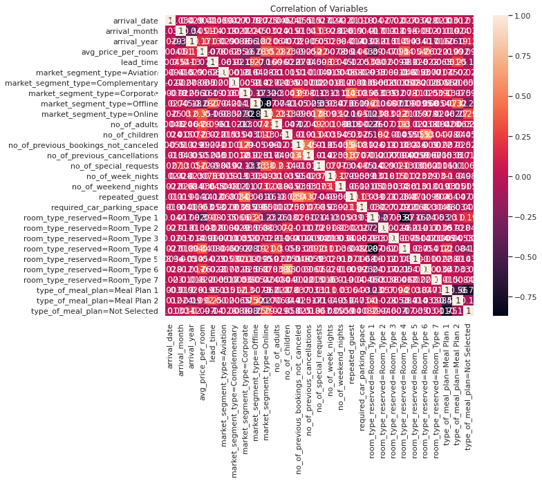

```
Variance Inflation Factors (VIF)
> 10: An indication that multicollinearity may be present
> 100: Certain multicollinearity among the variables
-------------------------------------
arrival_date: 1.0112305804628878
arrival_month: 1.2861328179646405
arrival_year: 1.4308628901117222
avg_price_per_room: 1.7331805550438593
lead_time: 1.363424038327931
market_segment_type=Aviation: inf
market_segment_type=Complementary: inf
market_segment_type=Corporate: inf
market_segment_type=Offline: inf
market_segment_type=Online: inf
no_of_adults: 1.3269460295742521
no_of_children: 1.5546113443407437
no_of_previous_bookings_not_canceled: 1.6020976879950675
no_of_previous_cancellations: 1.3190323661554026
no_of_special_requests: 1.2625540030909803
no_of_week_nights: 1.1028258853104125
no_of_weekend_nights: 1.0698632204534841
repeated_guest: 1.7007658414846847
required_car_parking_space: 1.0381565983441259
room_type_reserved=Room_Type 1: inf
room_type_reserved=Room_Type 2: inf
room_type_reserved=Room_Type 3: inf
room_type_reserved=Room_Type 4: inf
room_type_reserved=Room_Type 5: inf
room_type_reserved=Room_Type 6: inf
room_type_reserved=Room_Type 7: inf
type_of_meal_plan=Meal Plan 1: inf
type_of_meal_plan=Meal Plan 2: inf
type_of_meal_plan=Not Selected: inf

15 cases of possible multicollinearity
15 cases of definite multicollinearity

Assumption not satisfied

Coefficient interpretability will be problematic
Consider removing variables with a high Variance Inflation Factor (VIF)
```

```python
multicollinearity_assumption(log_reg_model, X_valid, y_train,dict_vec.get_feature_names())
```

## Final Model Summary

### Testing the final model

We’re almost ready to use it for risk scoring. We still need to do two things before we can use it:

- Retrain the final model on both train and validation datasets combined. We no longer need the validation dataset, so we can use more data for training, which will make the model slightly better.
- Test the model on the test set. This is the part of data we kept aside from the beginning. Now we use it to make sure the model didn’t overfit and performs well on completely unseen data.

The next steps are:

- Apply the same preprocessing to df_full_train and df_test as we did to df_train and df_val. As a result, we get the feature matrices X_train and X_test as well as our target variables y_train and y_test.
- Train a model on the combined dataset with the parameters we selected previously.
- Apply the model to the test data to get the test predictions.
- Verify that the model performs well and doesn’t overfit.

```python
## select the target variables from the dataframe
y_train = df_train_full.booking_status.values
y_test = df_test.booking_status.values
```

```python
## lets delete the target columns for trainig purposes
del df_train_full['booking_status']
del df_test['booking_status']
```

```python
## convert to dictionary list
train_dict = df_train_full.to_dict(orient='records')
test_dict = df_test.to_dict(orient='records')
```

```python
## convert the dictionary list to a  matrix form for training
dict_vec = DictVectorizer(sparse=False)

X_train_full = dict_vec.fit_transform(train_dict)
X_test = dict_vec.transform(test_dict)
```

```python
## lets instantiate the Logistic Regression model
## and train it on our dataset
model = LogisticRegression(solver='liblinear', random_state=11)
model.fit(X_train_full, y_train)
```

```
LogisticRegression(random_state=11, solver='liblinear')
```

```python
## lets generate some predictions on the test dataset
y_pred_test = model.predict_proba(X_test)[:,1]
```

```python
## lets compute our accuracy
test_auc_score = roc_auc_score(y_test, y_pred_test)
print(f"Test Accuracy {round(test_auc_score, 3)}")
```

```
Test Accuracy 0.857
```

## Building a Decision Tree model

```python
## import library
from sklearn.tree import DecisionTreeClassifier

## instantiate the Decision Tree classifier
dt_cl_model = DecisionTreeClassifier()

## train it the dataset
dt_cl_model.fit(X_train_full, y_train)
```

```
DecisionTreeClassifier()
```

```python
## lets make
y_train_pred = dt_cl_model.predict_proba(X_train_full)[:, 1]

## lets evaluate our model using the AUC
from sklearn.metrics import roc_auc_score

train_auc_score = roc_auc_score(y_train, y_train_pred)

print(f"Training Accuracy: {train_auc_score}")
```

```
Training Accuracy: 0.9998735951994807
```

```python
## lets generate some predictions on the test data
## lets check the accuracy on our validation dataset
y_valid_pred = dt_cl_model.predict_proba(X_valid)[:, 1]
```

```python
## lets evaluate our model using the AUC
from sklearn.metrics import roc_auc_score

valid_auc_score = roc_auc_score(y_valid, y_valid_pred)

print(f"Validation Accuracy: {valid_auc_score}")
```

```
Validation Accuracy: 0.9998528518051679
```

```python
## lets make
y_test_pred = dt_cl_model.predict_proba(X_test)[:, 1]

## lets evaluate our model using the AUC
from sklearn.metrics import roc_auc_score

train_auc_score = roc_auc_score(y_test, y_test_pred)

print(f"Testing Accuracy: {train_auc_score}")
```

```
Testing Accuracy: 0.8615739705893919
```

## Do we need to prune the tree?

- Yes, we noticied from the results of the above test accuracy, that the model has overfitted. Meaning the model has failed to generalize well unto the test data.

```python
## lets restrict the size of the tree by a depth of 2
dt_cl_model_2 = DecisionTreeClassifier(max_depth=2)
dt_cl_model_2.fit(X_train_full, y_train)
```

```
DecisionTreeClassifier(max_depth=2)
```

## Model Performance Comparison and Conclusions

```python
## lets make
y_train_pred = dt_cl_model_2.predict_proba(X_train_full)[:, 1]

## lets evaluate our model using the AUC
from sklearn.metrics import roc_auc_score

train_auc_score = roc_auc_score(y_train, y_train_pred)

print(f"Training Accuracy: {train_auc_score}")
```

```
Training Accuracy: 0.7622711832754732
```

```python
## lets make
y_test_pred = dt_cl_model_2.predict_proba(X_test)[:, 1]

## lets evaluate our model using the AUC
from sklearn.metrics import roc_auc_score

train_auc_score = roc_auc_score(y_test, y_test_pred)

print(f"Testing Accuracy: {train_auc_score}")
```

```
Testing Accuracy: 0.7654678207945222
```

From the Above results we noticed a significant drop in training accuracy as well as that of the testing accuracy. The corresponding points to the fact that, the decision tree model now generalizes well to the test data.

```python
!pip freeze > requirement_fullcode_hotel.txt
```